# Assignment 7: Visualization - Some aspects of ggplot2

*How to do it?*:

- Open the Rmarkdown file of this assignment (link) in Rstudio.
- Right under each **question**, insert a code chunk (you can use the hotkey `Ctrl + Alt + I` to add a code chunk) and code the solution for the question.
- `Knit` the rmarkdown file (hotkey: `Ctrl + Alt + K`) to export an html.
- Publish the html file to your Githiub Page.

*Submission*: Submit the link on Github of the assignment to Canvas

Use the data of your own. Produce the following types of plots and comment on each plot. Plots should be meaningful. If you use the data we used in class, make sure the plots are not the same as the ones in the slides. All plots should have title, caption, appropriate labels on x and y-axis.

```r
library(tidyverse)
setwd("C:/Users/student/Downloads")
df =  read_csv('Spotify-2023.csv')
head(df)
```

```
## # A tibble: 6 × 24
##   track_name          `artist(s)_name` artist_count released_year released_month
##   <chr>               <chr>                   <dbl>         <dbl>          <dbl>
## 1 Seven (feat. Latto… Latto, Jung Kook            2          2023              7
## 2 LALA                Myke Towers                 1          2023              3
## 3 vampire             Olivia Rodrigo              1          2023              6
## 4 Cruel Summer        Taylor Swift                1          2019              8
## 5 WHERE SHE GOES      Bad Bunny                   1          2023              5
## 6 Sprinter            Dave, Central C…            2          2023              6
## # ℹ 19 more variables: released_day <dbl>, in_spotify_playlists <dbl>,
## #   in_spotify_charts <dbl>, streams <chr>, in_apple_playlists <dbl>,
## #   in_apple_charts <dbl>, in_deezer_playlists <dbl>, in_deezer_charts <dbl>,
## #   in_shazam_charts <dbl>, bpm <dbl>, key <chr>, mode <chr>,
## #   `danceability_%` <dbl>, `valence_%` <dbl>, `energy_%` <dbl>,
## #   `acousticness_%` <dbl>, `instrumentalness_%` <dbl>, `liveness_%` <dbl>,
## #   `speechiness_%` <dbl>
```

1. Make a plot using `facet_wrap` by one categorical variable (`facet_wrap(~variable1)`)

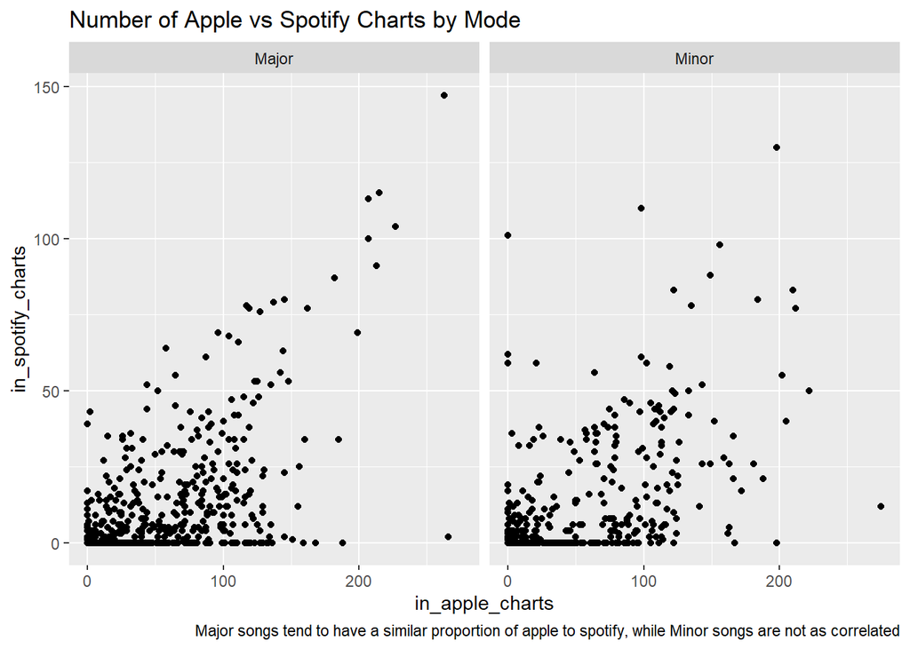

```r
df %>% ggplot()+
  geom_point(aes(x=in_apple_charts, y=in_spotify_charts))+facet_wrap(~mode)+
  labs(
       title = 'Number of Apple vs Spotify Charts by Mode',
       caption = 'Major songs tend to have a similar proportion of apple to spotify, while Minor songs are not as correlated')
```

```r
## songs on apple vs spotify charts by mode
```

2. Make a plot using `facet_wrap` by two categorical variables (`facet_wrap(~variable1+variable2)`)

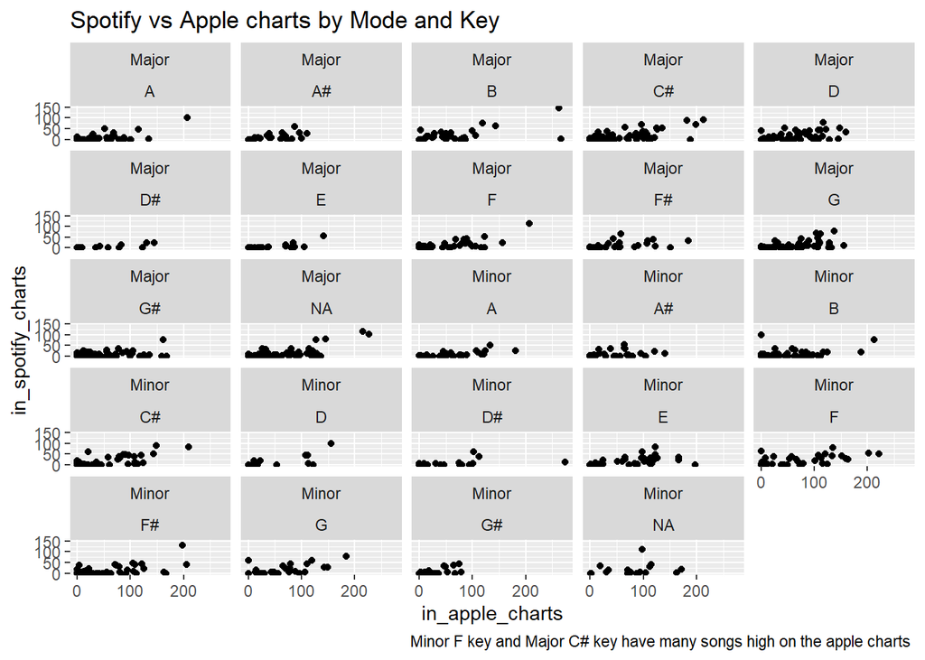

```r
df %>% ggplot()+
  geom_point(aes(x=in_apple_charts, y=in_spotify_charts))+facet_wrap(~mode+key)+labs(
       title = 'Spotify vs Apple charts by Mode and Key',
       caption = 'Minor F key and Major C# key have many songs high on the apple charts ')
```